# Tourism Master Dataset Parsing

## Data Sources Overview

### World Tourism Organization (UWTO)

> The United Nations agency responsible for the promotion of responsible, sustainable and universally accessible tourism.

#### Variables

- Inbound tourism
  - Arrivals - Thousands
  - Tourism expenditure in the country - US\$ Mn
  - Travel - US\$ Mn
  - Passenger transport - US\$ Mn
- Outbound tourism
  - Departures - Thousands
  - Tourism expenditure in other countries - US\$ Mn
  - Travel - US\$ Mn
  - Passenger transport - US\$ Mn

### World Development Indicators (table 6.14)

> The World Development Indicators is a compilation of relevant, high-quality, and internationally comparable statistics about global development and the fight against poverty. The data concerning tourism in the WDI is primarily from the UWTO, with supplementary data from IMF and World Bank.

#### Variables

- Inbound tourism
  - ST.INT.ARVL
    - International tourism, number of arrivals
    - International inbound tourists (overnight visitors) are the number of tourists who travel to a country other than that in which they have their usual residence, but outside their usual environment, for a period not exceeding 12 months and whose main purpose in visiting is other than an activity remunerated from within the country visited. When data on number of tourists are not available, the number of visitors, which includes tourists, same-day visitors, cruise passengers, and crew members, is shown instead. Sources and collection methods for arrivals differ across countries. In some cases data are from border statistics (police, immigration, and the like) and supplemented by border surveys.
  - ST.INT.RCPT.XP.ZS
    - International tourism, receipts (% of total exports)
    - International tourism receipts are expenditures by international inbound visitors, including payments to national carriers for international transport. These receipts include any other prepayment made for goods or services received in the destination country. They also may include receipts from same-day visitors, except when these are important enough to justify separate classification. For some countries they do not include receipts for passenger transport items. Their share in exports is calculated as a ratio to exports of goods and services, which comprise all transactions between residents of a country and the rest of the world involving a change of ownership from residents to nonresidents of general merchandise, goods sent for processing and repairs, nonmonetary gold, and services.
  - ST.INT.RCPT.CD
    - International tourism, receipts (current US\$)
    - International tourism receipts are expenditures by international inbound visitors, including payments to national carriers for international transport. These receipts include any other prepayment made for goods or services received in the destination country. They also may include receipts from same-day visitors, except when these are important enough to justify separate classification. For some countries they do not include receipts for passenger transport items. Data are in current U.S. dollars.
  - ST.INT.TRNR.CD
    - International tourism, receipts for passenger transport items (current US\$)
    - International tourism receipts for passenger transport items are expenditures by international inbound visitors for all services provided in the international transportation by resident carriers. Also included are passenger services performed within an economy by nonresident carriers. Excluded are passenger services provided to nonresidents by resident carriers within the resident economies; these are included in travel items. In addition to the services covered by passenger fares--including fares that are a part of package tours but excluding cruise fares, which are included in travel--passenger services include such items as charges for excess baggage, vehicles, or other personal accompanying effects and expenditures for food, drink, or other items for which passengers make expenditures while on board carriers. Data are in current U.S. dollars.
  - ST.INT.TVLR.CD
    - International tourism, receipts for travel items (current US\$)
    - International tourism receipts for travel items are expenditures by international inbound visitors in the reporting economy. The goods and services are purchased by, or on behalf of, the traveler or provided, without a quid pro quo, for the traveler to use or give away. These receipts should include any other prepayment made for goods or services received in the destination country. They also may include receipts from same-day visitors, except in cases where these are so important as to justify a separate classification. Excluded is the international carriage of travelers, which is covered in passenger travel items. Data are in current U.S. dollars.
- Outbound tourism
  - ST.INT.XPND.MP.ZS
    - International tourism, expenditures (\% of total imports)
    - International tourism expenditures are expenditures of international outbound visitors in other countries, including payments to foreign carriers for international transport. These expenditures may include those by residents traveling abroad as same-day visitors, except in cases where these are important enough to justify separate classification. For some countries they do not include expenditures for passenger transport items. Their share in imports is calculated as a ratio to imports of goods and services, which comprise all transactions between residents of a country and the rest of the world involving a change of ownership from nonresidents to residents of general merchandise, goods sent for processing and repairs, nonmonetary gold, and services.
  - ST.INT.XPND.CD
    - International tourism, expenditures (current US\$)
    - International tourism expenditures are expenditures of international outbound visitors in other countries, including payments to foreign carriers for international transport. These expenditures may include those by residents traveling abroad as same-day visitors, except in cases where these are important enough to justify separate classification. For some countries they do not include expenditures for passenger transport items. Data are in current U.S. dollars.
  - ST.INT.TRNX.CD
    - International tourism, expenditures for passenger transport items (current US\$)
    - International tourism expenditures for passenger transport items are expenditures of international outbound visitors in other countries for all services provided during international transportation by nonresident carriers. Also included are passenger services performed within an economy by nonresident carriers. Excluded are passenger services provided to nonresidents by resident carriers within the resident economies; these are included in travel items. In addition to the services covered by passenger fares--including fares that are a part of package tours but excluding cruise fares, which are included in travel--passenger services include such items as charges for excess baggage, vehicles, or other personal accompanying effects and expenditures for food, drink, or other items for which passengers make expenditures while on board carriers. Data are in current U.S. dollars.
  - ST.INT.TVLX.CD
    - International tourism, expenditures for travel items (current US\$)
    - International tourism expenditures are expenditures of international outbound visitors in other countries. The goods and services are purchased by, or on behalf of, the traveler or provided, without a quid pro quo, for the traveler to use or give away. These may include expenditures by residents traveling abroad as same-day visitors, except in cases where these are so important as to justify a separate classification. Excluded is the international carriage of travelers, which is covered in passenger travel items. Data are in current U.S. dollars.
  - ST.INT.DPRT
    - International tourism, number of departures
    - International outbound tourists are the number of departures that people make from their country of usual residence to any other country for any purpose other than a remunerated activity in the country visited. The data on outbound tourists refer to the number of departures, not to the number of people traveling. Thus a person who makes several trips from a country during a given period is counted each time as a new departure.

## Data Comparison

### Variable Comparison

[output not shown]

All of the data from the UWTO dataset appears to be included in the WDI data. The WDI dataset has two additional indicators that are computed as a percentage of total imports and exports.

$ \frac{(ST.INT.RCPT.CD|ST.INT.XPND.CD)}{sum(exports|imports)} * 100 $

```python
import pandas as pd
pd.set_option('display.float_format', lambda x: '%.3f' % x)
```

```python
# Read dataframes from processing notebook
uwto = pd.read_pickle("../data/Tourism/UWTO.pickle")
wdi = pd.read_pickle("../data/Tourism/WDI.pickle")
```

```python
# create lists of Years and Countries for both datasets
uwto_years = uwto['Year'].unique().tolist()
wdi_years = wdi['Year'].unique().tolist()
uwto_countries = uwto['Country Code'].unique().tolist()
wdi_countries = wdi['Country Code'].unique().tolist()
```

### Countries Included

```python
# create lists of countries unique to each dataset
uwto_unique = str([x for x in uwto_countries if x not in wdi_countries])
wdi_unique = str([x for x in wdi_countries if x not in uwto_countries])
```

### Variable Characteristics

> UWTO data has to be transformed to standard single units and identically labeled for comparison

```python
uwto_units = pd.DataFrame({
                            'Country Code': uwto['Country Code'],
                            'Year': uwto['Year'],
                            'ST.INT.ARVL': uwto['Inbound: Arrivals - Thousands'].apply(lambda x: x * 1000),
                            'ST.INT.XPND.CD': uwto['Outbound: Tourism expenditure in other countries - US$ Mn'].apply(lambda x: x * 1000000),
                            'ST.INT.TRNX.CD': uwto['Outbound: Passenger transport - US$ Mn'].apply(lambda x: x * 1000000),
                            'ST.INT.TVLX.CD': uwto['Outbound: Travel - US$ Mn'].apply(lambda x: x * 1000000),
                            'ST.INT.DPRT': uwto['Outbound: Departures - Thousands'].apply(lambda x: x * 1000),
                            'ST.INT.RCPT.CD': uwto['Inbound: Tourism expenditure in the country - US$ Mn'].apply(lambda x: x * 1000000),
                            'ST.INT.TRNR.CD': uwto['Inbound: Passenger transport - US$ Mn'].apply(lambda x: x * 1000000),
                            'ST.INT.TVLR.CD': uwto['Inbound: Travel - US$ Mn'].apply(lambda x: x * 1000000),
                                })
```

```python
wdi[(wdi['Year']>1994)].describe()
```

|  | ST.INT.ARVL | ST.INT.XPND.MP.ZS | ST.INT.XPND.CD | ST.INT.TRNX.CD | ST.INT.TVLX.CD | ST.INT.DPRT | ST.INT.RCPT.XP.ZS | ST.INT.RCPT.CD | ST.INT.TRNR.CD | ST.INT.TVLR.CD | Year |
| --- | --- | --- | --- | --- | --- | --- | --- | --- | --- | --- | --- |
| count | 4390.000 | 3748.000 | 4055.000 | 3289.000 | 3956.000 | 2234.000 | 3752.000 | 4266.000 | 3033.000 | 3985.000 | 5160.000 |
| mean | 4417208.200 | 6.605 | 4828076388.212 | 794672287.039 | 4228815999.141 | 8031308.268 | 16.952 | 4928297940.752 | 922708154.258 | 4476780046.173 | 2006.500 |
| std | 10272868.297 | 4.332 | 15399011971.733 | 2718791242.890 | 13733953517.299 | 16159876.350 | 18.848 | 14801029019.088 | 2995992210.148 | 12946159292.781 | 6.923 |
| min | 700.000 | 0.183 | 100000.000 | 100000.000 | 10000.000 | 1900.000 | 0.001 | 100000.000 | 11000.000 | 100000.000 | 1995.000 |
| 25% | 199000.000 | 3.696 | 97000000.000 | 21000000.000 | 71000000.000 | 486250.000 | 4.269 | 119250000.000 | 17000000.000 | 107000000.000 | 2000.750 |
| 50% | 800000.000 | 5.579 | 423000000.000 | 87000000.000 | 329367300.000 | 1957000.000 | 9.356 | 660000000.000 | 128000000.000 | 578000000.000 | 2006.500 |
| 75% | 3513500.000 | 8.303 | 2628500000.000 | 375000000.000 | 2240000000.000 | 7331250.000 | 22.104 | 3372000000.000 | 593000000.000 | 3204000000.000 | 2012.250 |
| max | 86861000.000 | 42.441 | 257733000000.000 | 38896000000.000 | 257733000000.000 | 143035000.000 | 170.479 | 251361000000.000 | 44071000000.000 | 210748000000.000 | 2018.000 |

```python
uwto_units.describe()
```

|  | Year | ST.INT.ARVL | ST.INT.XPND.CD | ST.INT.TRNX.CD | ST.INT.TVLX.CD | ST.INT.DPRT | ST.INT.RCPT.CD | ST.INT.TRNR.CD | ST.INT.TVLR.CD |
| --- | --- | --- | --- | --- | --- | --- | --- | --- | --- |
| count | 4784.000 | 4443.000 | 3362.000 | 3258.000 | 3918.000 | 2232.000 | 3293.000 | 2960.000 | 3912.000 |
| mean | 2006.000 | 4353298.382 | 4721673395.234 | 840985896.905 | 4413844638.249 | 8088750.793 | 5044589334.038 | 913754118.992 | 4369168477.702 |
| std | 6.634 | 10188841.756 | 13993577827.374 | 2748006432.447 | 13907250089.380 | 16163715.919 | 15781899104.096 | 3013909725.017 | 12919374220.871 |
| min | 1995.000 | 700.000 | 100000.000 | 100000.000 | 10000.000 | 500.000 | 400000.000 | 11000.000 | 100000.000 |
| 25% | 2000.000 | 187000.000 | 114250000.000 | 22000000.000 | 67000000.000 | 451500.000 | 177000000.000 | 17000000.000 | 106000000.000 |
| 50% | 2006.000 | 769000.000 | 442000000.000 | 96000000.000 | 326000000.000 | 2022000.000 | 746000000.000 | 128000000.000 | 574500000.000 |
| 75% | 2012.000 | 3470000.000 | 2700750000.000 | 423000000.000 | 2410750000.000 | 7773750.000 | 3441000000.000 | 593000000.000 | 3056500000.000 |
| max | 2017.000 | 86861000.000 | 173919000000.000 | 38896000000.000 | 257733000000.000 | 143035000.000 | 251361000000.000 | 44071000000.000 | 210748000000.000 |

### Missing Data

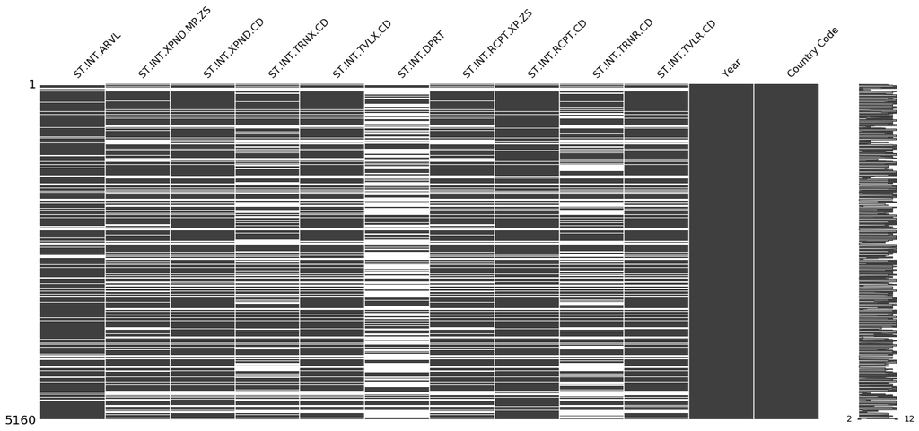

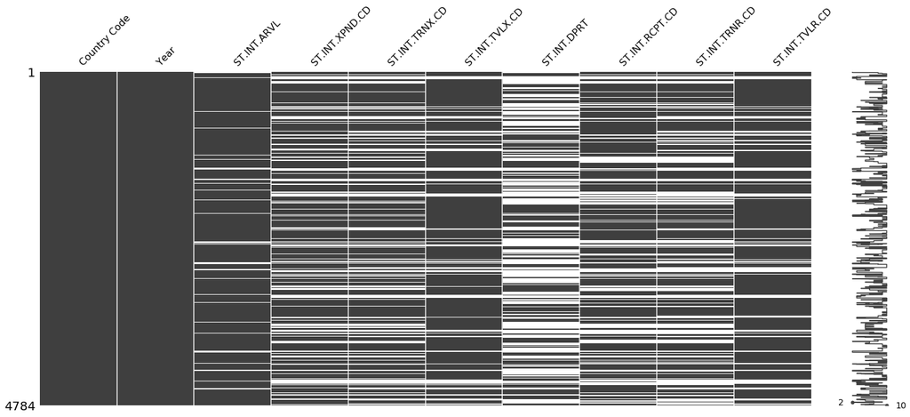

```python
# Visualize missing data for easier comparison

import missingno as msno
%matplotlib inline
msno.matrix(wdi[(wdi['Year']>1994)])
msno.matrix(uwto_units)
```

## Data Combining

```python
# Set DF indexes for join
wdi_indexed = wdi.set_index(["Country Code","Year"])
uwto_indexed = uwto_units.set_index(["Country Code","Year"])
```

```python
# left join no overwriting
wdi_indexed.update(uwto_indexed, overwrite=False)
```

```python
# reset DF index
wdi_indexed.reset_index(inplace=True)
```

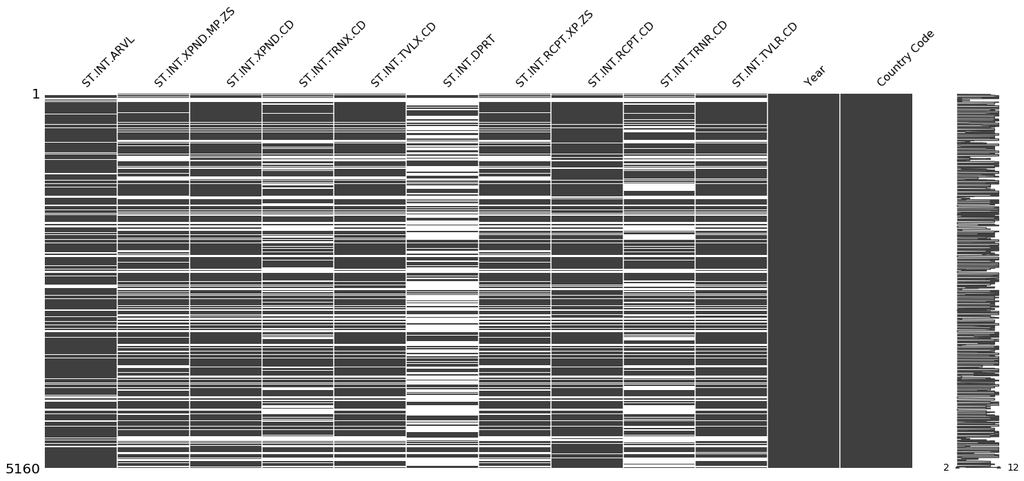

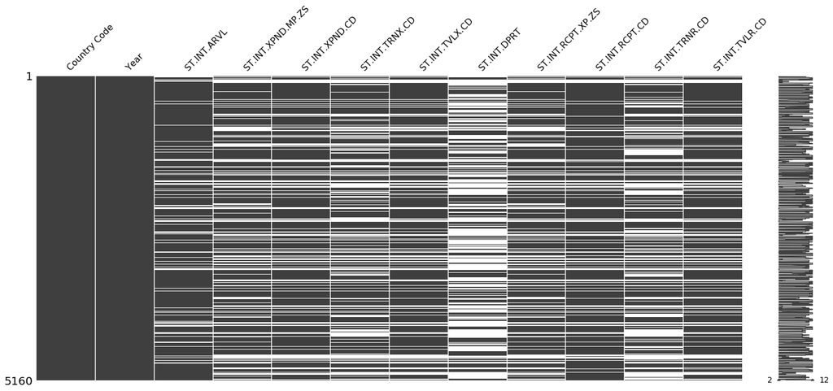

```python
# visualize missing values for before and after comparison
%matplotlib inline
msno.matrix(wdi[(wdi['Year']>1994)])
msno.matrix(wdi_indexed[(wdi_indexed['Year']>1994)])
```

## Saving Final Data

There are visibly fewer missing values in the data after the merge function. The data can now be saved for analysis and combination with other datasets.

```python
wdi_indexed.to_pickle("../data/Tourism.pickle")
```